# Road to Zero Fatality

## Introduction

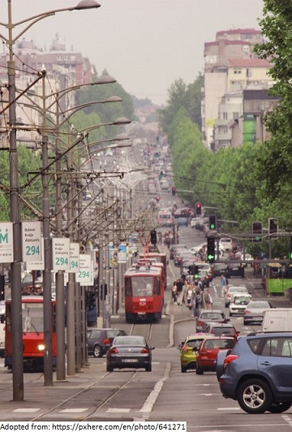

In 2015, the UN rolled out the **2030 Agenda for Sustainable Development**.In Sustainable Development Goals 3.6, the UN is committed to halve the road accident fatalities and injuries world wide.

> **"SDG 3.6: By 2020, halve the number of global deaths and injuries from road traffic accidents."**

This Shiny application is created in 2019, within one year before the proposed deadline. The 2005-2015 UK road Accident dataset is obtained from: https://www.kaggle.com/silicon99/dft-accident-data. This app offer the UK public a visualization tool on the fatal road accidents in UK and the infographics associated with them.

In the following slides, we will discuss on our **Data Science Process**, **App Description** and our **Experience**.

## Data Science Process

**Asking an interesting question:**  
In conjunction with UN Sustainable Development Goals 3.6, we want to know what is the historical trend and infographic associated with Fatal Road Accidents in UK.

**Get the Data:**  
The 2005-2015 UK road Accident dataset contained all road accidents reported.  
https://www.kaggle.com/silicon99/dft-accident-data.

**Explore the Data:**  
head(), summary(), str(), and boxplot() are used to understand dataset, identify missing values, and gauge fittings of the data.

**Model the Data:**  
Data is cleaned, integrated and transformed in order to work with shiny and visualization tools.

**Communicate and Visualize the result:**  
Data visualization is available on github and shiny io, slides on rpubs.

## App Description

[figure not shown]

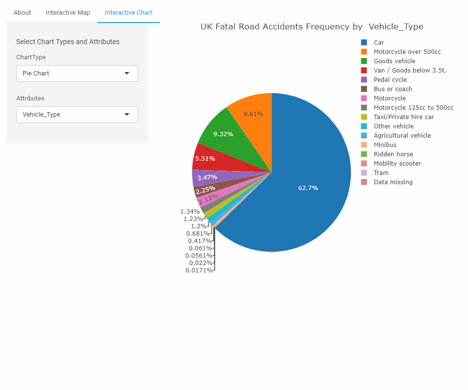

## Experience

As with all new learning experience, we had our struggles with getting things to work. We learned the hard way that the code that worked on our local machine does not necessarily work on the cloud server. There are always little bit and pieces of details that can go wrong.

Visualization is an important tool for all data scientist. We are glad that we have a new tool handy in our pocket now.

Link to our app is as follow:  
- Shiny App: https://enjunz.shinyapps.io/uk_fatal_accidents_2005-2015_visualization/  
- Source Code: https://github.com/EnJunChoong/RoadToZeroFatality  
**Please initiate from rstudio to run Shiny from github if the free 25hrs perMonth capacity on shinyapps.io has been reach:

```r
library('shiny')
runGitHub("RoadToZeroFatality", "EnJunChoong")
```